# TITLE by Anfeng Yu

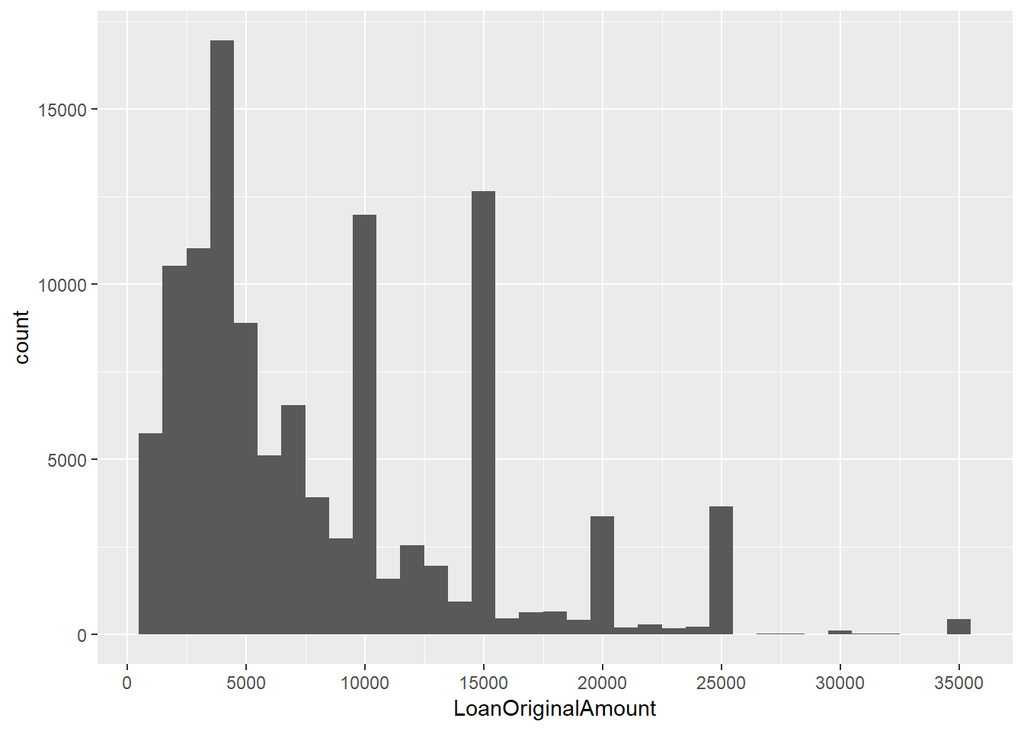

Most cumtomers’ original loan amout is under $15000, and many of customers loan $5000, $10000, $15000, $20000, $25000. Very few cumstomers loan more than $25000.

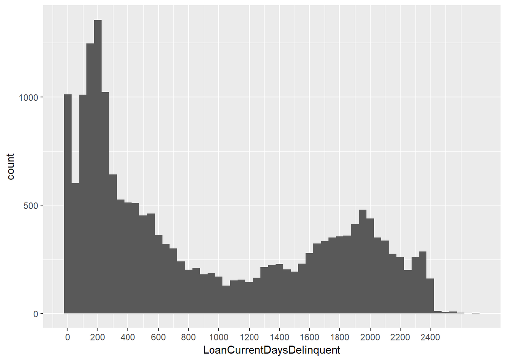

This graph is kind like 2 normal distribution’s combination. We can make the guess: Among the customers who have loan delinquent, there are two major kinds, one usually has about less delinquent days(about 200 days), but the another kind has much more days(about 2000 days).

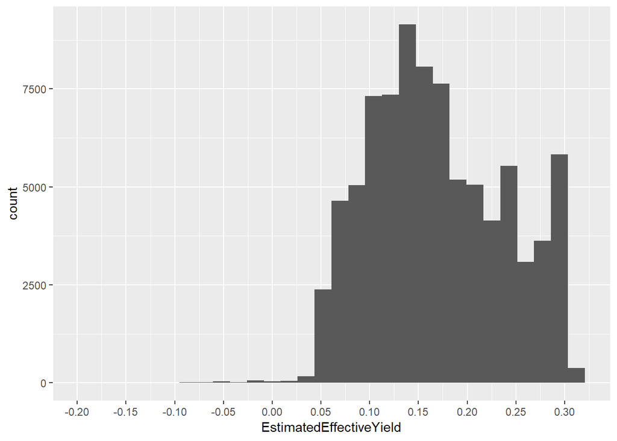

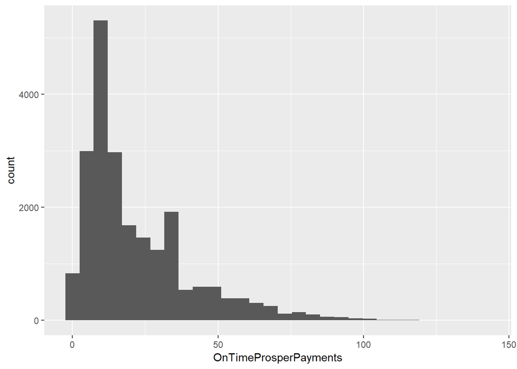

# Univariate Analysis

### What is the structure of your dataset?

The prosperLoanData is a set of each customers’ loan and personal information data.For each customer, this data set has his/her loan amount and rate, salary and job, also estimated effictive yield(earned money).

### What is/are the main feature(s) of interest in your dataset?

By my exploration, I think main feature is estimatedEffctiveYield, because this feature reveal by this customer how much interest we company can make.

### What other features in the dataset do you think will help support your investigation into your feature(s) of interest?

First,IncomeRange, StatedMonthlyIncome and LoanOriginalAmount, these features help me to figure out if this person has the ability to pay his loan. Second OnTimeProsperPayments, creditGrade can show if this customer can usually pay his loan.

### Did you create any new variables from existing variables in the dataset?

No.

### Of the features you investigated, were there any unusual distributions? Did you perform any operations on the data to tidy, adjust, or change the form of the data? If so, why did you do this?

LoanCurrentDaysDelinquent has a unusual distribution, because most data are 0.

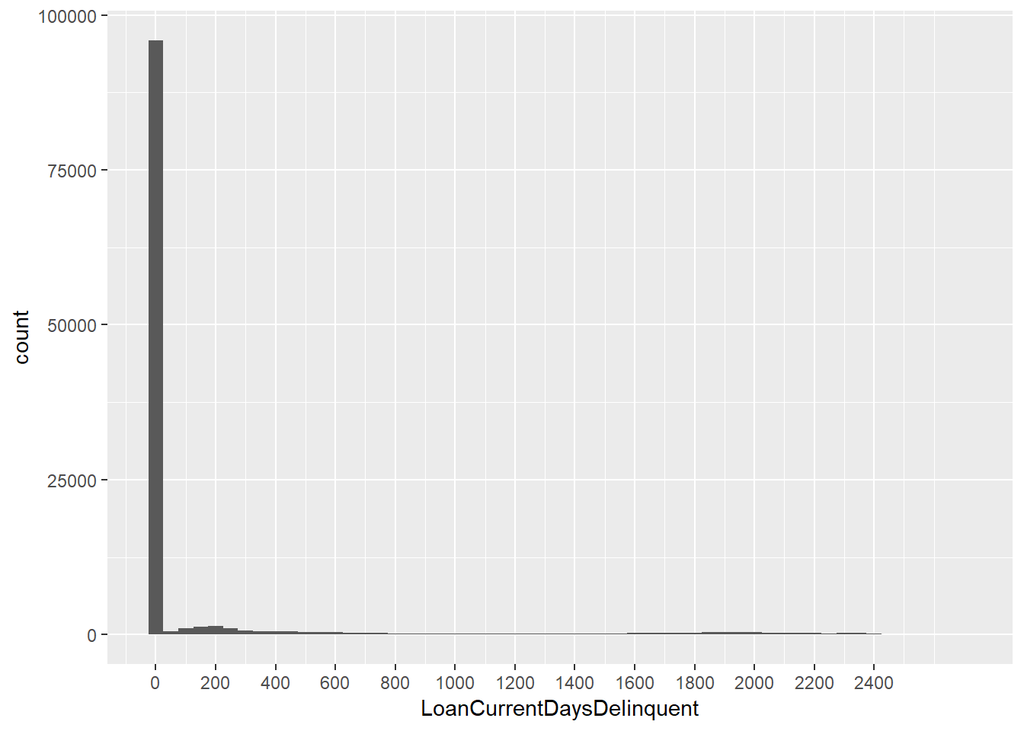

I chose to use data with LoanData$LoanCurrentDaysDelinquent > 0.

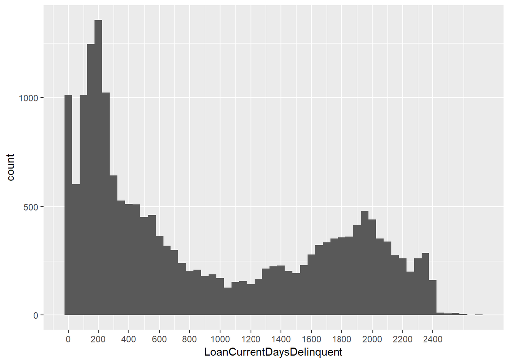

# Bivariate Plots Section

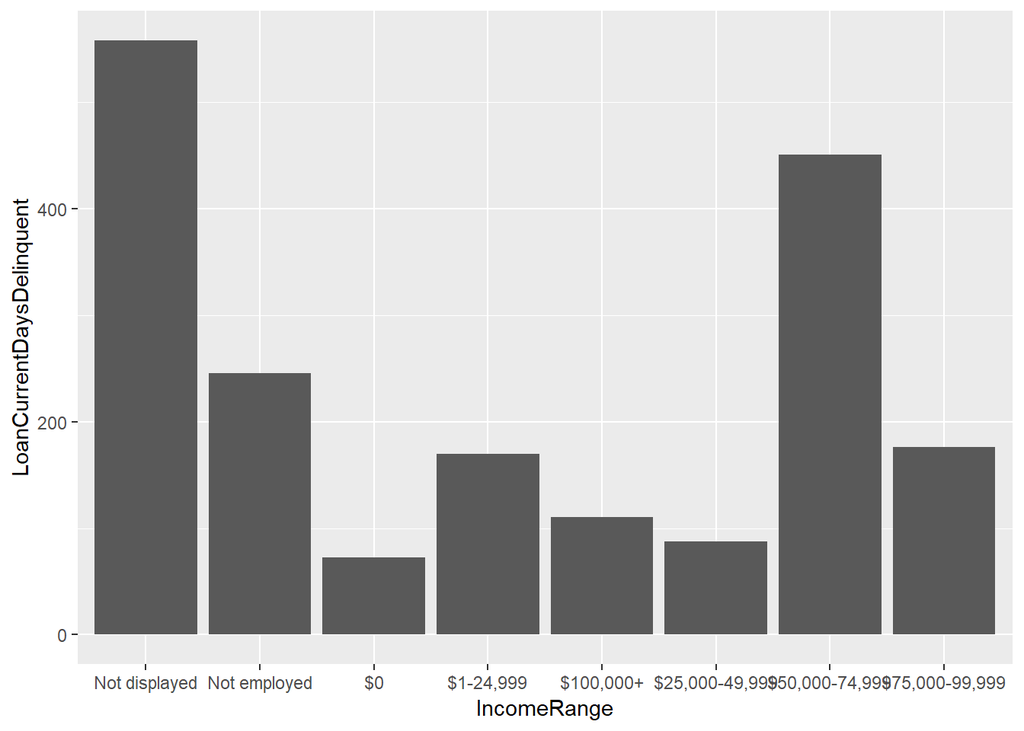

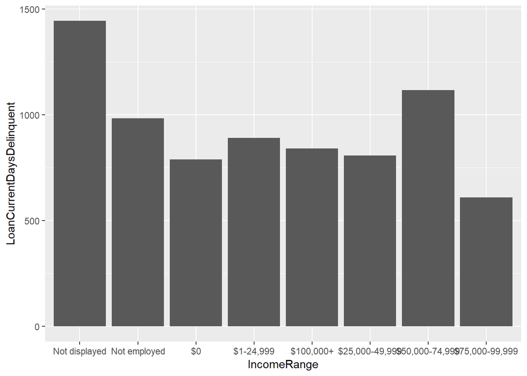

```
## [1] 0.38647343 0.24965631 0.09199977 0.19073062 0.13169082 0.10859541
## [7] 0.40395298 0.28908189
```

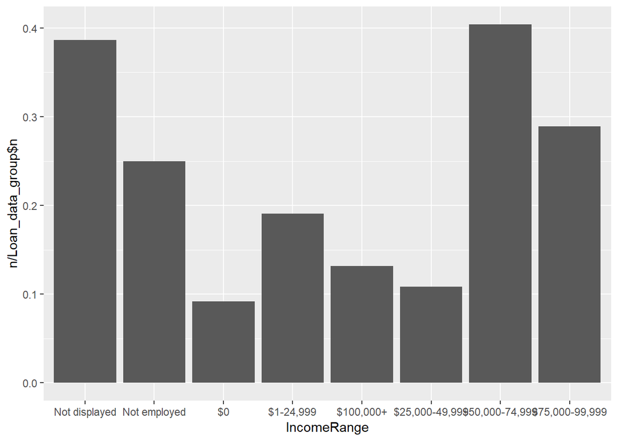

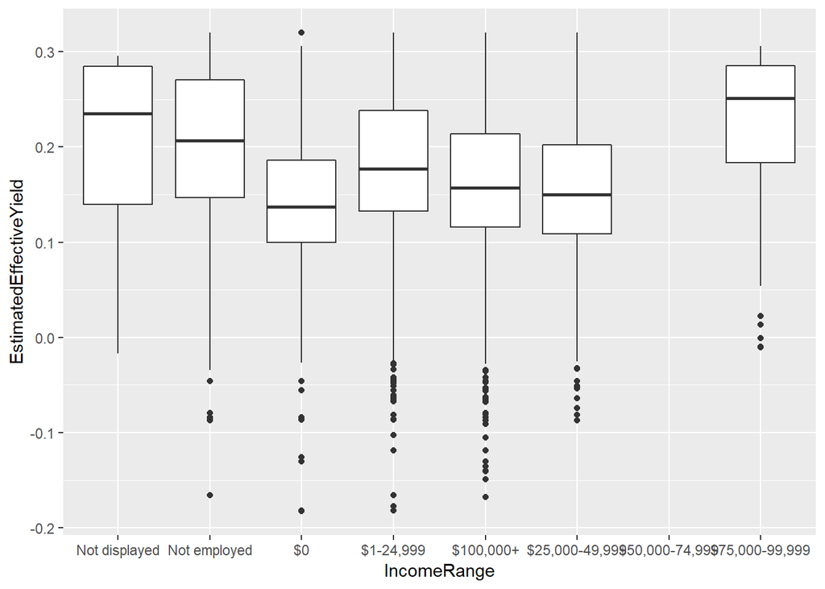

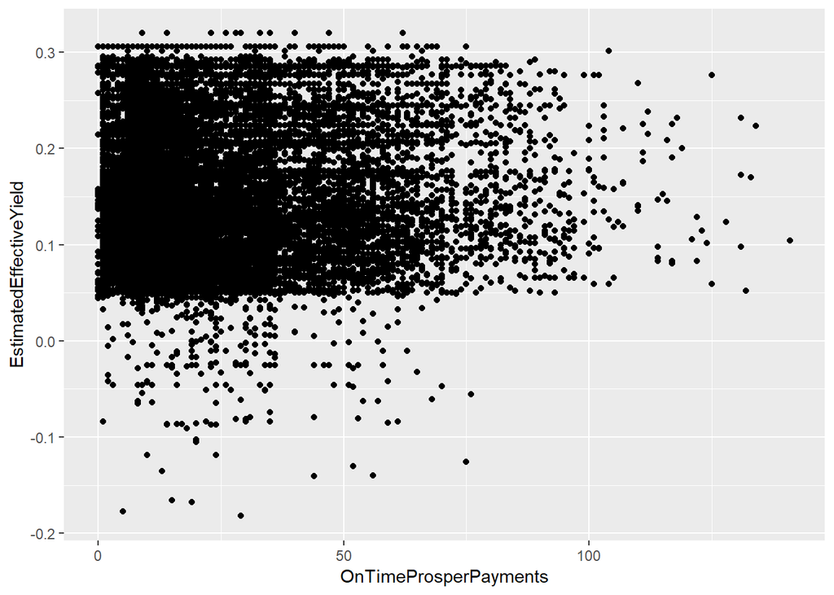

```
## [1] -0.01120913
```

There is no siginificant relationship between EstimatedEffectiveYield and OnTimeProsperPayments.

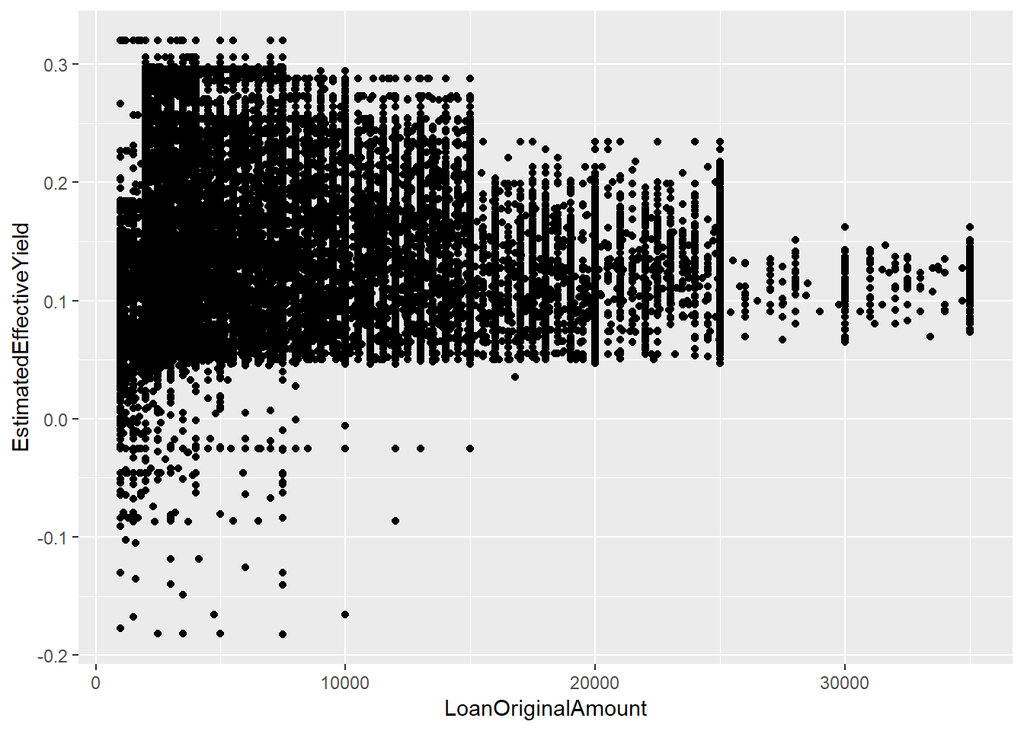

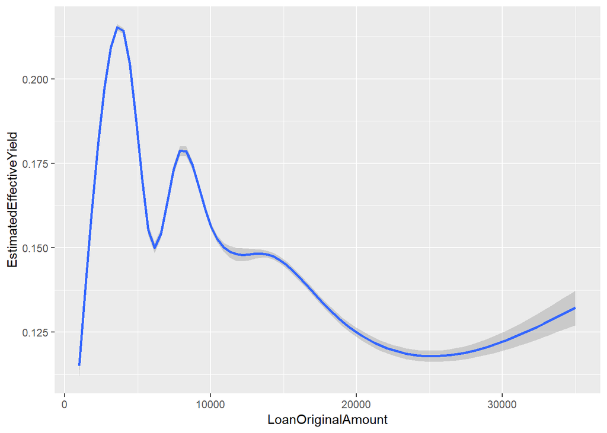

```
## [1] -0.3272657
```

It’s easy to see, with lower loan original amount (less than $15000), there is a much higher EstimatedEffectiveYield.

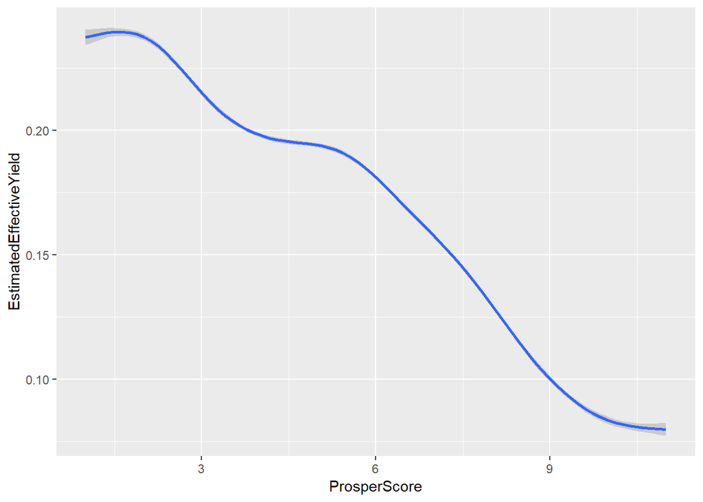

```
## [1] -0.6320034
```

Also, there is a strong relationship between ProsperScore and EstimatedEffectiveYield. The higher ProsperScore is, the less EstimatedEffectiveYield is.

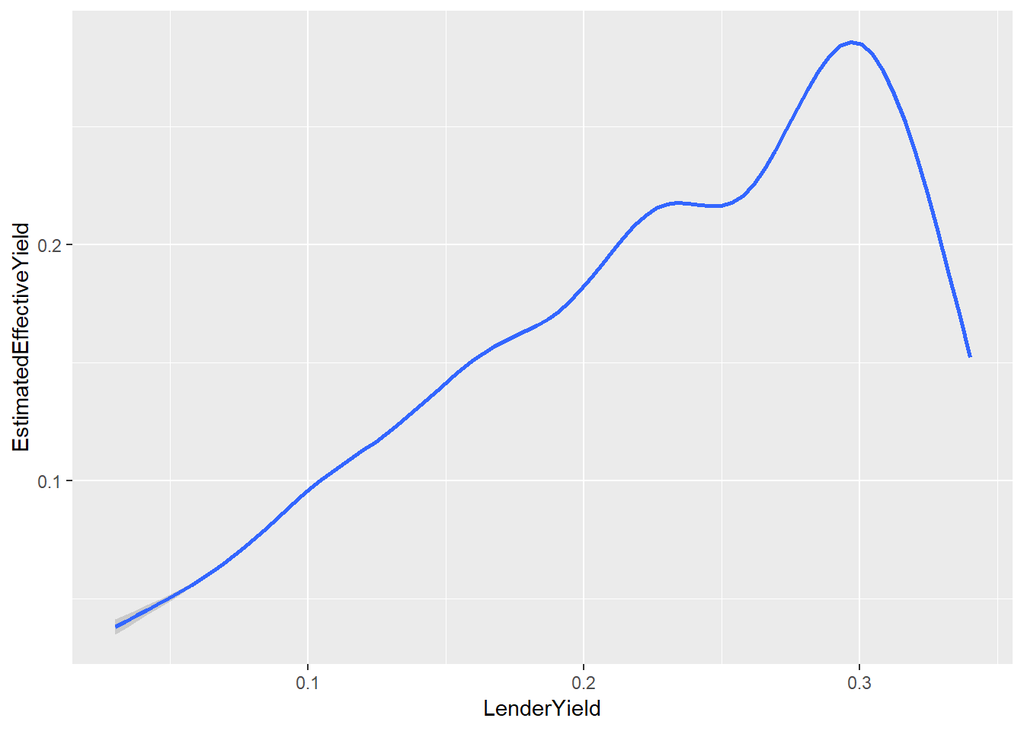

```
## [1] 0.8953425
```

There is a very strong positive ratio relationship between LenderYield and EstimatedEffectiveYield, however when LenderYield is higher than 0.3, EstimatedEffectiveYield goes downwards.

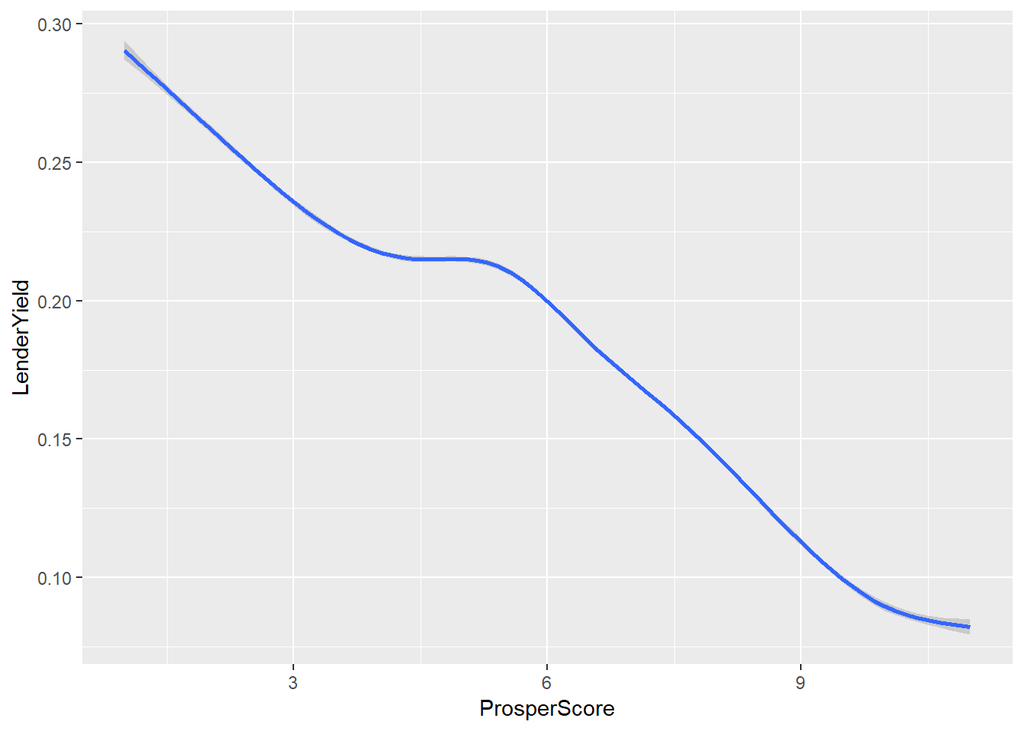

```
## [1] -0.6497835
```

The relationship is even more obvious for LenderYield and ProsperScore.

# Bivariate Analysis

> **Tip**: As before, summarize what you found in your bivariate explorations here. Use the questions below to guide your discussion.

### Talk about some of the relationships you observed in this part of the investigation. How did the feature(s) of interest vary with other features in the dataset?

For IncomeRange in $50,000 ~ $74,999, there is no data for EstimatedEffectiveYield.

### What was the strongest relationship you found?

There is a very strong positive ratio relationship between LenderYield and EstimatedEffectiveYield, however when LenderYield is higher than 0.3, EstimatedEffectiveYield goes downwards.

# Multivariate Plots Section

> **Tip**: Now it’s time to put everything together. Based on what you found in the bivariate plots section, create a few multivariate plots to investigate more complex interactions between variables. Make sure that the plots that you create here are justified by the plots you explored in the previous section. If you plan on creating any mathematical models, this is the section where you will do that.

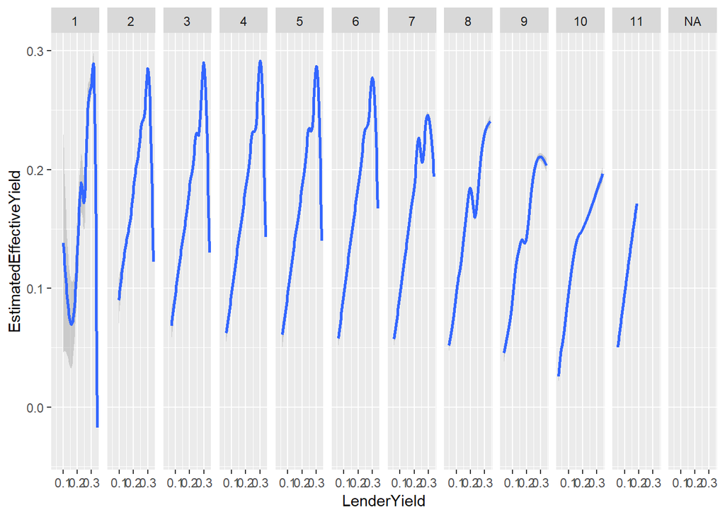

These plots(x is LenderYield, y is EstimatedEffectiveYield, faceted by ProsperScore) clearly show that, generally LenderYield has a positive ratio relationship with EstimatedEffectiveYield, and EstimatedEffectiveYield will decrease a little with ProsperScore’s increasing.

# Multivariate Analysis

### Talk about some of the relationships you observed in this part of the investigation. Were there features that strengthened each other in terms of looking at your feature(s) of interest?

These plots(x is LenderYield, y is EstimatedEffectiveYield, faceted by ProsperScore) clearly show that, generally LenderYield has a positive ratio relationship with EstimatedEffectiveYield, and EstimatedEffectiveYield will decrease a little with ProsperScore’s increasing.

### OPTIONAL: Did you create any models with your dataset? Discuss the strengths and limitations of your model.

# Final Plots and Summary

> **Tip**: You’ve done a lot of exploration and have built up an understanding of the structure of and relationships between the variables in your dataset. Here, you will select three plots from all of your previous exploration to present here as a summary of some of your most interesting findings. Make sure that you have refined your selected plots for good titling, axis labels (with units), and good aesthetic choices (e.g. color, transparency). After each plot, make sure you justify why you chose each plot by describing what it shows.

### Plot One

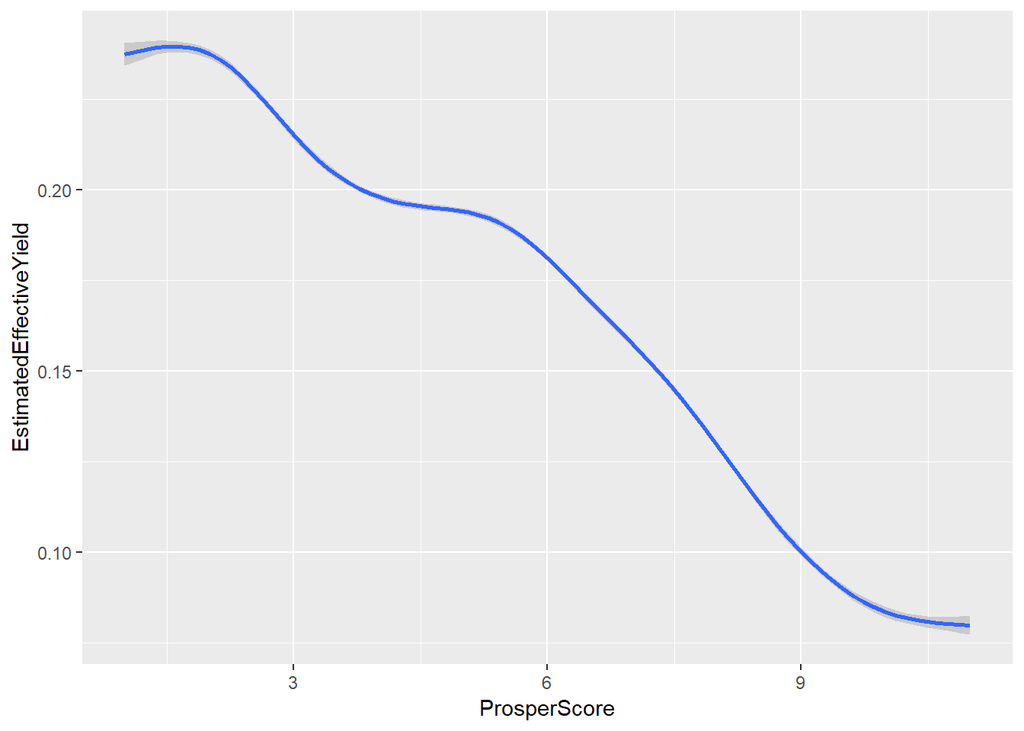

### Description One

there is a strong relationship between ProsperScore and EstimatedEffectiveYield. The higher ProsperScore is, the less EstimatedEffectiveYield is.

### Plot Two

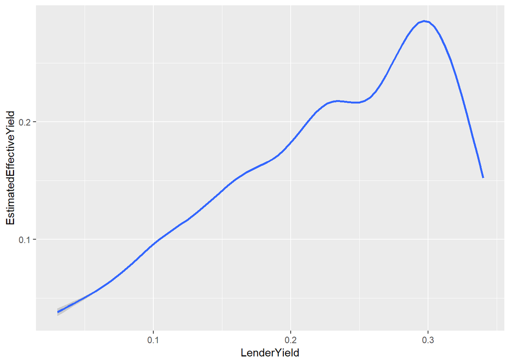

### Description Two

There is a very strong positive ratio relationship between LenderYield and EstimatedEffectiveYield, however when LenderYield is higher than 0.3, EstimatedEffectiveYield goes downwards.

### Plot Three

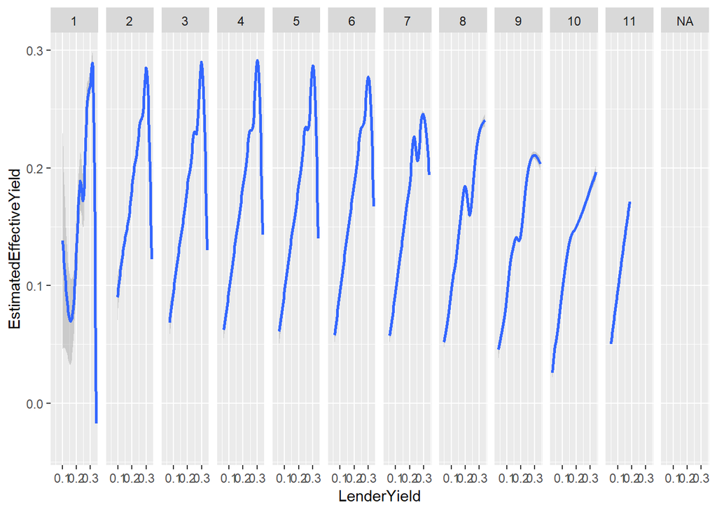

## These plots(x is LenderYield, y is EstimatedEffectiveYield, faceted by ProsperScore) clearly show that, generally LenderYield has a positive ratio relationship with EstimatedEffectiveYield, and EstimatedEffectiveYield will decrease a little with ProsperScore’s increasing.

# Reflection

For this project, my most siginificant obstacle is to find what is the main feature. After investigating of the data’ meaning, I decide EstimatedEffectiveYield as the main feature.

Then, by bivariate and multivariate exploration, I find generally LenderYield has a positive ratio relationship with EstimatedEffectiveYield, and EstimatedEffectiveYield will decrease a little with ProsperScore’s increasing.